# Cetacean Strandings in the Pacific Northwest

Amanda J. Warlick$^1$

$^1$School of Aquatic and Fishery Science, University of Washington, Seattle, WA

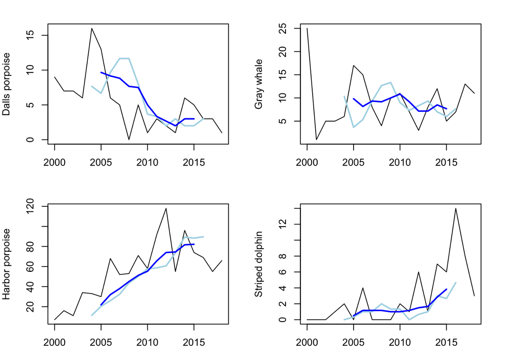

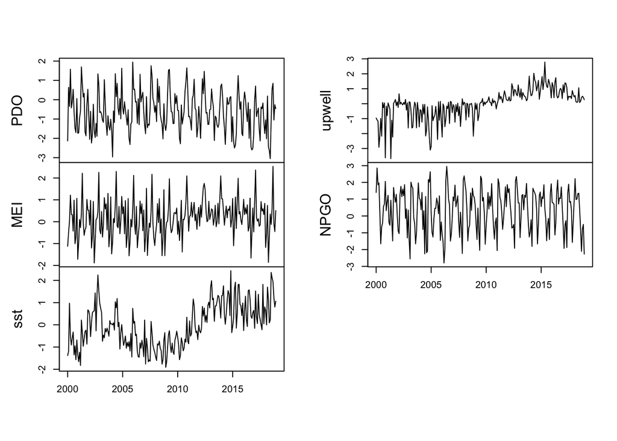

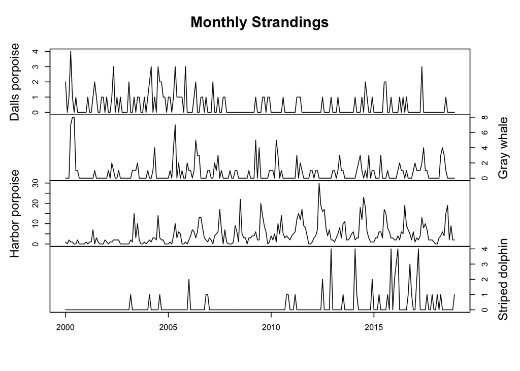

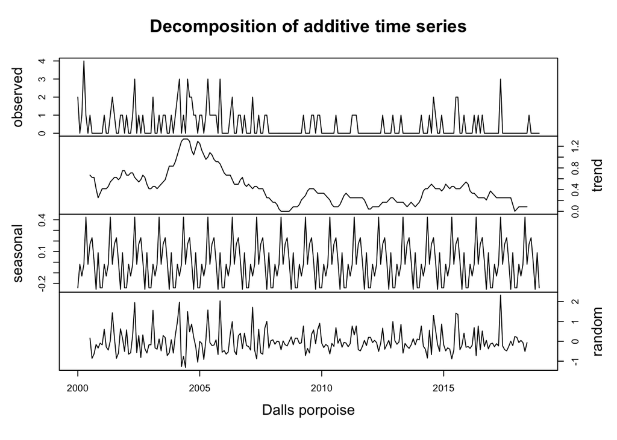

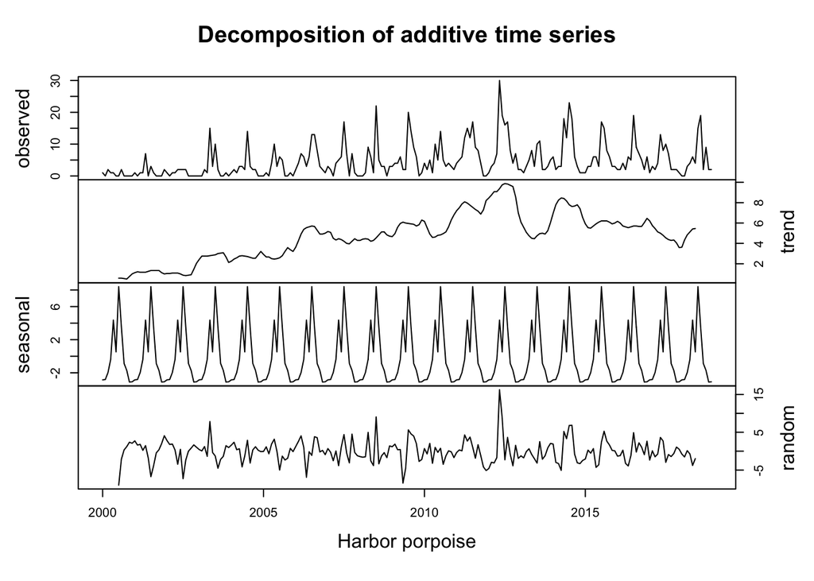

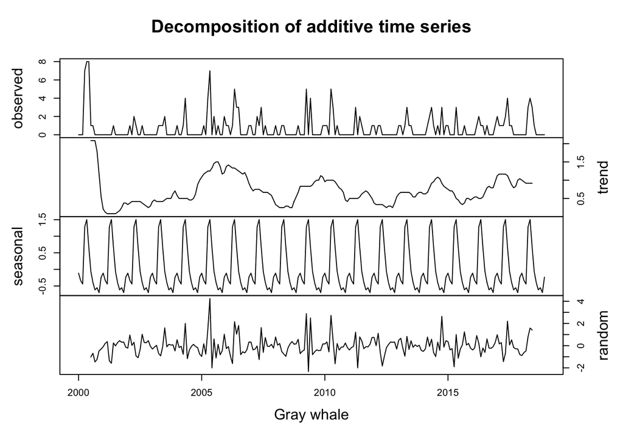

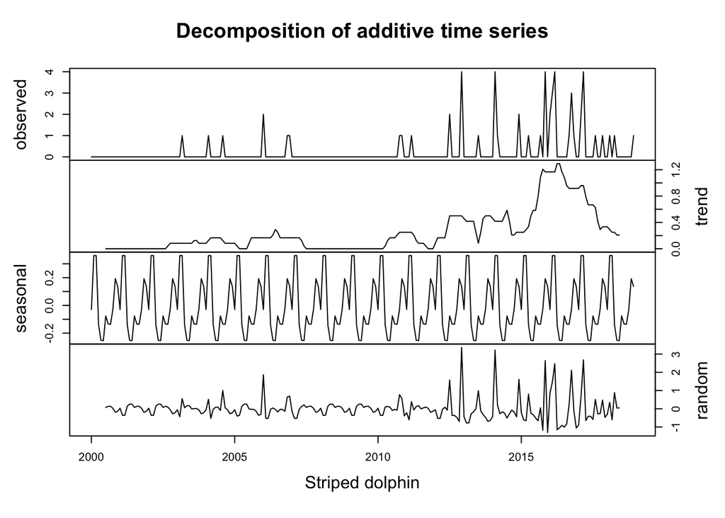

Annual level marss model

```
## Success! abstol and log-log tests passed at 25 iterations.
## Alert: conv.test.slope.tol is 0.5.
## Test with smaller values (<0.1) to ensure convergence.
##
## MARSS fit is
## Estimation method: kem
## Convergence test: conv.test.slope.tol = 0.5, abstol = 0.001
## Estimation converged in 25 iterations.
## Log-likelihood: -77.4175
## AIC: 172.835   AICc: 175.5623
##
##                                     Estimate
## R.(Dalls porpoise,Dalls porpoise)     0.3944
## R.(Gray whale,Gray whale)             0.4893
## R.(Harbor porpoise,Harbor porpoise)   0.0688
## R.(Striped dolphin,Striped dolphin)   0.3808
## Q.diag                                0.0702
## x0.X.Dalls porpoise                   2.0409
## x0.X.Gray whale                       1.9001
## x0.X.Harbor porpoise                  2.2650
## x0.X.Striped dolphin                  0.0915
## Initial states (x0) defined at t=0
##
## Standard errors have not been calculated.
## Use MARSSparamCIs to compute CIs and bias estimates.
```

```
## Success! abstol and log-log tests passed at 28 iterations.
## Alert: conv.test.slope.tol is 0.5.
## Test with smaller values (<0.1) to ensure convergence.
##
## MARSS fit is
## Estimation method: kem
## Convergence test: conv.test.slope.tol = 0.5, abstol = 0.001
## Estimation converged in 28 iterations.
## Log-likelihood: -76.62538
## AIC: 173.2508   AICc: 176.6354
##
##                                     Estimate
## R.(Dalls porpoise,Dalls porpoise)     0.4169
## R.(Gray whale,Gray whale)             0.4926
## R.(Harbor porpoise,Harbor porpoise)   0.0705
## R.(Striped dolphin,Striped dolphin)   0.3830
## U.1                                   0.0419
## Q.diag                                0.0607
## x0.X.Dalls porpoise                   1.8927
## x0.X.Gray whale                       1.7556
## x0.X.Harbor porpoise                  2.2257
## x0.X.Striped dolphin                 -0.0227
## Initial states (x0) defined at t=0
##
## Standard errors have not been calculated.
## Use MARSSparamCIs to compute CIs and bias estimates.
```

```
## Success! abstol and log-log tests passed at 655 iterations.
## Alert: conv.test.slope.tol is 0.5.
## Test with smaller values (<0.1) to ensure convergence.
##
## MARSS fit is
## Estimation method: kem
## Convergence test: conv.test.slope.tol = 0.5, abstol = 0.001
## Estimation converged in 655 iterations.
## Log-likelihood: -72.23937
## AIC: 164.4787   AICc: 167.8633
##
##                      Estimate
## R.diag                 0.3919
## U.X.Dalls porpoise    -0.0931
## U.X.Gray whale         0.0208
## U.X.Harbor porpoise    0.1022
## U.X.Striped dolphin    0.1121
## Q.diag                 0.0000
## x0.X.Dalls porpoise    2.2793
## x0.X.Gray whale        1.7954
## x0.X.Harbor porpoise   2.7990
## x0.X.Striped dolphin  -0.3781
## Initial states (x0) defined at t=0
##
## Standard errors have not been calculated.
## Use MARSSparamCIs to compute CIs and bias estimates.
```

```
## Warning! Abstol convergence only. Maxit (=1500) reached before log-log convergence.
##
## MARSS fit is
## Estimation method: kem
## Convergence test: conv.test.slope.tol = 0.5, abstol = 0.001
## WARNING: Abstol convergence only no log-log convergence.
##  maxit (=1500) reached before log-log convergence.
##  The likelihood and params might not be at the ML values.
##  Try setting control$maxit higher.
## Log-likelihood: -72.26115
## AIC: 170.5223   AICc: 176.3933
##
##                                          Estimate
## R.diag                                   3.92e-01
## U.X.Dalls porpoise                      -9.32e-02
## U.X.Gray whale                           2.08e-02
## U.X.Harbor porpoise                      1.03e-01
## U.X.Striped dolphin                      1.12e-01
## Q.(X.Dalls porpoise,X.Dalls porpoise)    3.91e-05
## Q.(X.Gray whale,X.Gray whale)            0.00e+00
## Q.(X.Harbor porpoise,X.Harbor porpoise)  4.68e-05
## Q.(X.Striped dolphin,X.Striped dolphin)  3.64e-05
## x0.X.Dalls porpoise                      2.28e+00
## x0.X.Gray whale                          1.80e+00
## x0.X.Harbor porpoise                     2.79e+00
## x0.X.Striped dolphin                    -3.74e-01
## Initial states (x0) defined at t=0
##
## Standard errors have not been calculated.
## Use MARSSparamCIs to compute CIs and bias estimates.
##
## Convergence warnings
##  Warning: the  Q.(X.Dalls porpoise,X.Dalls porpoise)  parameter value has not converged.
##  Warning: the  Q.(X.Harbor porpoise,X.Harbor porpoise)  parameter value has not converged.
##  Warning: the  Q.(X.Striped dolphin,X.Striped dolphin)  parameter value has not converged.
##  Type MARSSinfo("convergence") for more info on this warning.
```

```
## Warning! Abstol convergence only. Maxit (=500) reached before log-log convergence.
##
## MARSS fit is
## Estimation method: kem
## Convergence test: conv.test.slope.tol = 0.5, abstol = 0.001
## WARNING: Abstol convergence only no log-log convergence.
##  maxit (=500) reached before log-log convergence.
##  The likelihood and params might not be at the ML values.
##  Try setting control$maxit higher.
## Log-likelihood: -67.86048
## AIC: 167.721   AICc: 176.9413
##
##                                          Estimate
## R.(Dalls porpoise,Dalls porpoise)        0.458068
## R.(Gray whale,Gray whale)                0.480264
## R.(Harbor porpoise,Harbor porpoise)      0.071860
## R.(Striped dolphin,Striped dolphin)      0.417919
## U.X.Dalls porpoise                      -0.093255
## U.X.Gray whale                           0.020873
## U.X.Harbor porpoise                      0.111361
## U.X.Striped dolphin                      0.111622
## Q.(X.Dalls porpoise,X.Dalls porpoise)    0.000154
## Q.(X.Gray whale,X.Gray whale)            0.000127
## Q.(X.Harbor porpoise,X.Harbor porpoise)  0.052246
## Q.(X.Striped dolphin,X.Striped dolphin)  0.000133
## x0.X.Dalls porpoise                      2.282058
## x0.X.Gray whale                          1.794514
## x0.X.Harbor porpoise                     2.134120
## x0.X.Striped dolphin                    -0.370865
## Initial states (x0) defined at t=0
##
## Standard errors have not been calculated.
## Use MARSSparamCIs to compute CIs and bias estimates.
##
## Convergence warnings
##  Warning: the  Q.(X.Dalls porpoise,X.Dalls porpoise)  parameter value has not converged.
##  Warning: the  Q.(X.Gray whale,X.Gray whale)  parameter value has not converged.
##  Warning: the  Q.(X.Striped dolphin,X.Striped dolphin)  parameter value has not converged.
##  Type MARSSinfo("convergence") for more info on this warning.
```

```
## Success! abstol and log-log tests passed at 215 iterations.
## Alert: conv.test.slope.tol is 0.5.
## Test with smaller values (<0.1) to ensure convergence.
##
## MARSS fit is
## Estimation method: kem
## Convergence test: conv.test.slope.tol = 0.5, abstol = 0.001
## Estimation converged in 215 iterations.
## Log-likelihood: -71.21979
## AIC: 170.4396   AICc: 177.3248
##
##                                     Estimate
## R.(Dalls porpoise,Dalls porpoise)     0.4479
## R.(Gray whale,Gray whale)             0.5007
## R.(Harbor porpoise,Harbor porpoise)   0.0993
## R.(Striped dolphin,Striped dolphin)   0.4063
## U.X.Dalls porpoise                   -0.0924
## U.X.Gray whale                        0.0215
## U.X.Harbor porpoise                   0.1070
## U.X.Striped dolphin                   0.1088
## Q.diag                                0.0195
## Q.offdiag                            -0.0063
## x0.X.Dalls porpoise                   2.3981
## x0.X.Gray whale                       1.8825
## x0.X.Harbor porpoise                  2.3590
## x0.X.Striped dolphin                 -0.1904
## Initial states (x0) defined at t=0
##
## Standard errors have not been calculated.
## Use MARSSparamCIs to compute CIs and bias estimates.
```

```
##               U       R          Q     AICc   delAIC
## 1      No trend   Equal      Equal 175.5623 7.698932
## 2     One trend   Equal      Equal 176.6354 8.772022
## 3 Unique trends   Equal      Equal 167.8633 0.000000
## 4 Unique trends   Equal    Unequal 176.3933 8.529917
## 5 Unique trends Unequal    Unequal 176.9413 9.077954
## 6 Unique trends Unequal Correlated 177.3248 9.461485
```

```
##
## MARSS fit is
## Estimation method: kem
## Convergence test: conv.test.slope.tol = 0.5, abstol = 0.001
## Estimation converged in 655 iterations.
## Log-likelihood: -72.23937
## AIC: 164.4787   AICc: 167.8633
##
##                       ML.Est Std.Err   low.CI    up.CI
## R.diag                0.3919 0.07139  0.25194  0.53179
## U.X.Dalls porpoise   -0.0931 0.02698 -0.14598 -0.04021
## U.X.Gray whale        0.0208 0.02629 -0.03073  0.07233
## U.X.Harbor porpoise   0.1022 0.03016  0.04310  0.16132
## U.X.Striped dolphin   0.1121 0.02694  0.05932  0.16493
## Q.diag                0.0000 0.00325 -0.00637  0.00637
## x0.X.Dalls porpoise   2.2793 0.30107  1.68925  2.86941
## x0.X.Gray whale       1.7954 0.29939  1.20859  2.38218
## x0.X.Harbor porpoise  2.7990 0.30547  2.20030  3.39773
## x0.X.Striped dolphin -0.3781 0.29989 -0.96583  0.20970
## Initial states (x0) defined at t=0
##
## CIs calculated at alpha = 0.05 via method=hessian
```

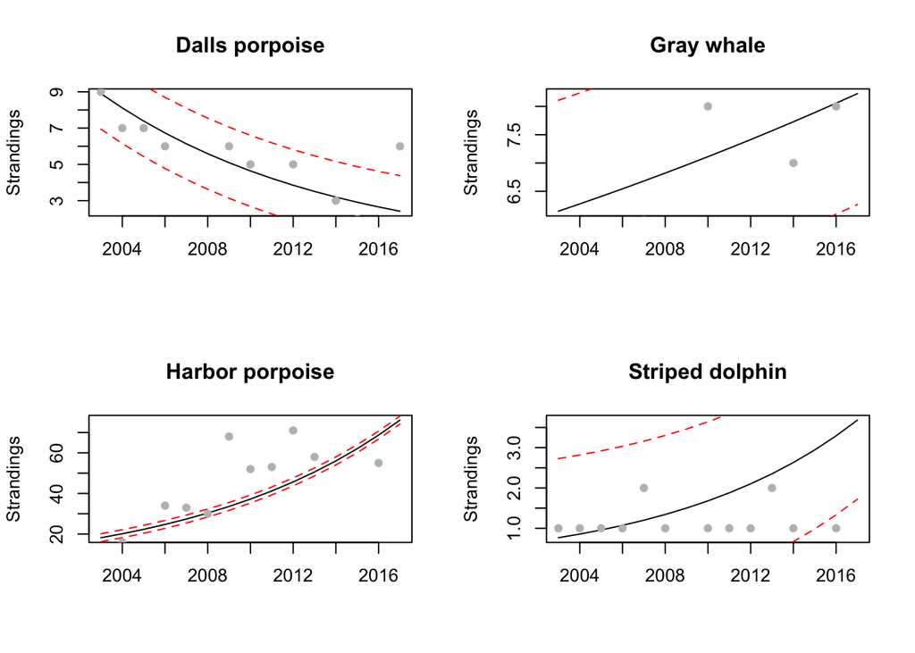

```
## Success! abstol and log-log tests passed at 623 iterations.
## Alert: conv.test.slope.tol is 0.5.
## Test with smaller values (<0.1) to ensure convergence.
##
## MARSS fit is
## Estimation method: kem
## Convergence test: conv.test.slope.tol = 0.5, abstol = 0.001
## Estimation converged in 623 iterations.
## Log-likelihood: -68.53167
## AIC: 165.0633   AICc: 171.9486
##
##                      Estimate
## R.diag                 0.3554
## U.X.Dalls porpoise    -0.1340
## U.X.Gray whale        -0.0140
## U.X.Harbor porpoise    0.1169
## U.X.Striped dolphin    0.0794
## Q.diag                 0.0000
## x0.X.Dalls porpoise    2.1045
## x0.X.Gray whale        1.7466
## x0.X.Harbor porpoise   2.9308
## x0.X.Striped dolphin  -0.3315
## C.X.Dalls porpoise     0.2766
## C.X.Gray whale         0.2353
## C.X.Harbor porpoise   -0.0994
## C.X.Striped dolphin    0.2215
## Initial states (x0) defined at t=1
##
## Standard errors have not been calculated.
## Use MARSSparamCIs to compute CIs and bias estimates.
```

```
## Success! abstol and log-log tests passed at 655 iterations.
## Alert: conv.test.slope.tol is 0.5.
## Test with smaller values (<0.1) to ensure convergence.
##
## MARSS fit is
## Estimation method: kem
## Convergence test: conv.test.slope.tol = 0.5, abstol = 0.001
## Estimation converged in 655 iterations.
## Log-likelihood: -69.85065
## AIC: 167.7013   AICc: 174.5865
##
##                      Estimate
## R.diag                0.36799
## U.X.Dalls porpoise   -0.00409
## U.X.Gray whale        0.13202
## U.X.Harbor porpoise   0.06867
## U.X.Striped dolphin   0.16992
## Q.diag                0.00000
## x0.X.Dalls porpoise   2.14133
## x0.X.Gray whale       1.76016
## x0.X.Harbor porpoise  2.91852
## x0.X.Striped dolphin -0.29525
## C.X.Dalls porpoise    0.12424
## C.X.Gray whale        0.15527
## C.X.Harbor porpoise  -0.04678
## C.X.Striped dolphin   0.08066
## Initial states (x0) defined at t=1
##
## Standard errors have not been calculated.
## Use MARSSparamCIs to compute CIs and bias estimates.
```

```
## Success! abstol and log-log tests passed at 561 iterations.
## Alert: conv.test.slope.tol is 0.5.
## Test with smaller values (<0.1) to ensure convergence.
##
## MARSS fit is
## Estimation method: kem
## Convergence test: conv.test.slope.tol = 0.5, abstol = 0.001
## Estimation converged in 561 iterations.
## Log-likelihood: -67.62635
## AIC: 163.2527   AICc: 170.1379
##
##                      Estimate
## R.diag                 0.3471
## U.X.Dalls porpoise    -0.0884
## U.X.Gray whale         0.0246
## U.X.Harbor porpoise    0.0963
## U.X.Striped dolphin    0.1167
## Q.diag                 0.0000
## x0.X.Dalls porpoise    2.4416
## x0.X.Gray whale        2.0249
## x0.X.Harbor porpoise   2.5818
## x0.X.Striped dolphin  -0.0181
## C.X.Dalls porpoise     0.4386
## C.X.Gray whale         0.3582
## C.X.Harbor porpoise   -0.5492
## C.X.Striped dolphin    0.4257
## Initial states (x0) defined at t=1
##
## Standard errors have not been calculated.
## Use MARSSparamCIs to compute CIs and bias estimates.
```

```
## Success! abstol and log-log tests passed at 694 iterations.
## Alert: conv.test.slope.tol is 0.5.
## Test with smaller values (<0.1) to ensure convergence.
##
## MARSS fit is
## Estimation method: kem
## Convergence test: conv.test.slope.tol = 0.5, abstol = 0.001
## Estimation converged in 694 iterations.
## Log-likelihood: -71.40223
## AIC: 170.8045   AICc: 177.6897
##
##                      Estimate
## R.diag                 0.3833
## U.X.Dalls porpoise    -0.0939
## U.X.Gray whale         0.0247
## U.X.Harbor porpoise    0.1162
## U.X.Striped dolphin    0.1204
## Q.diag                 0.0000
## x0.X.Dalls porpoise    2.1970
## x0.X.Gray whale        1.7616
## x0.X.Harbor porpoise   2.7061
## x0.X.Striped dolphin  -0.3813
## C.X.Dalls porpoise     0.0480
## C.X.Gray whale        -0.2429
## C.X.Harbor porpoise   -0.8704
## C.X.Striped dolphin   -0.5108
## Initial states (x0) defined at t=1
##
## Standard errors have not been calculated.
## Use MARSSparamCIs to compute CIs and bias estimates.
```

```
## Success! abstol and log-log tests passed at 647 iterations.
## Alert: conv.test.slope.tol is 0.5.
## Test with smaller values (<0.1) to ensure convergence.
##
## MARSS fit is
## Estimation method: kem
## Convergence test: conv.test.slope.tol = 0.5, abstol = 0.001
## Estimation converged in 647 iterations.
## Log-likelihood: -69.65547
## AIC: 167.3109   AICc: 174.1962
##
##                      Estimate
## R.diag                 0.3661
## U.X.Dalls porpoise    -0.0824
## U.X.Gray whale         0.0760
## U.X.Harbor porpoise    0.0566
## U.X.Striped dolphin    0.1172
## Q.diag                 0.0000
## x0.X.Dalls porpoise    2.2482
## x0.X.Gray whale        2.1396
## x0.X.Harbor porpoise   2.6348
## x0.X.Striped dolphin  -0.2371
## C.X.Dalls porpoise    -0.0284
## C.X.Gray whale        -0.1477
## C.X.Harbor porpoise    0.1219
## C.X.Striped dolphin   -0.0134
## Initial states (x0) defined at t=1
##
## Standard errors have not been calculated.
## Use MARSSparamCIs to compute CIs and bias estimates.
```

```
## Success! abstol and log-log tests passed at 696 iterations.
## Alert: conv.test.slope.tol is 0.5.
## Test with smaller values (<0.1) to ensure convergence.
##
## MARSS fit is
## Estimation method: kem
## Convergence test: conv.test.slope.tol = 0.5, abstol = 0.001
## Estimation converged in 696 iterations.
## Log-likelihood: -64.68063
## AIC: 157.3613   AICc: 164.7297
##
##                      Estimate
## R.diag                 0.3530
## U.X.Dalls porpoise    -0.0932
## U.X.Gray whale         0.0489
## U.X.Harbor porpoise    0.0717
## U.X.Striped dolphin    0.1206
## Q.diag                 0.0000
## x0.X.Dalls porpoise    2.0845
## x0.X.Gray whale        1.5361
## x0.X.Harbor porpoise   3.0019
## x0.X.Striped dolphin  -0.1544
## C.X.Dalls porpoise    -0.0119
## C.X.Gray whale         0.0224
## C.X.Harbor porpoise   -0.4370
## C.X.Striped dolphin    0.1200
## Initial states (x0) defined at t=1
##
## Standard errors have not been calculated.
## Use MARSSparamCIs to compute CIs and bias estimates.
```

```
## Success! abstol and log-log tests passed at 677 iterations.
## Alert: conv.test.slope.tol is 0.5.
## Test with smaller values (<0.1) to ensure convergence.
##
## MARSS fit is
## Estimation method: kem
## Convergence test: conv.test.slope.tol = 0.5, abstol = 0.001
## Estimation converged in 677 iterations.
## Log-likelihood: -63.25603
## AIC: 154.5121   AICc: 161.8805
##
##                      Estimate
## R.diag                 0.3393
## U.X.Dalls porpoise    -0.0935
## U.X.Gray whale         0.0665
## U.X.Harbor porpoise    0.0938
## U.X.Striped dolphin    0.0977
## Q.diag                 0.0000
## x0.X.Dalls porpoise    2.0988
## x0.X.Gray whale        1.2800
## x0.X.Harbor porpoise   3.0763
## x0.X.Striped dolphin   0.0507
## C.X.Dalls porpoise     0.0357
## C.X.Gray whale        -1.0651
## C.X.Harbor porpoise   -0.6080
## C.X.Striped dolphin    1.1448
## Initial states (x0) defined at t=1
##
## Standard errors have not been calculated.
## Use MARSSparamCIs to compute CIs and bias estimates.
```

```
## Success! abstol and log-log tests passed at 695 iterations.
## Alert: conv.test.slope.tol is 0.5.
## Test with smaller values (<0.1) to ensure convergence.
##
## MARSS fit is
## Estimation method: kem
## Convergence test: conv.test.slope.tol = 0.5, abstol = 0.001
## Estimation converged in 695 iterations.
## Log-likelihood: -64.35032
## AIC: 156.7006   AICc: 164.0691
##
##                      Estimate
## R.diag                 0.3498
## U.X.Dalls porpoise    -0.1385
## U.X.Gray whale         0.1577
## U.X.Harbor porpoise    0.0737
## U.X.Striped dolphin    0.0715
## Q.diag                 0.0000
## x0.X.Dalls porpoise    2.1259
## x0.X.Gray whale        1.4408
## x0.X.Harbor porpoise   3.2236
## x0.X.Striped dolphin  -0.1777
## C.X.Dalls porpoise    -0.0604
## C.X.Gray whale         0.1449
## C.X.Harbor porpoise   -0.0128
## C.X.Striped dolphin   -0.0606
## Initial states (x0) defined at t=1
##
## Standard errors have not been calculated.
## Use MARSSparamCIs to compute CIs and bias estimates.
```

```
## Success! abstol and log-log tests passed at 694 iterations.
## Alert: conv.test.slope.tol is 0.5.
## Test with smaller values (<0.1) to ensure convergence.
##
## MARSS fit is
## Estimation method: kem
## Convergence test: conv.test.slope.tol = 0.5, abstol = 0.001
## Estimation converged in 694 iterations.
## Log-likelihood: -63.95954
## AIC: 155.9191   AICc: 163.2875
##
##                      Estimate
## R.diag                 0.3460
## U.X.Dalls porpoise    -0.0890
## U.X.Gray whale         0.0109
## U.X.Harbor porpoise    0.0912
## U.X.Striped dolphin    0.1221
## Q.diag                 0.0000
## x0.X.Dalls porpoise    2.1029
## x0.X.Gray whale        1.4080
## x0.X.Harbor porpoise   3.2405
## x0.X.Striped dolphin  -0.1981
## C.X.Dalls porpoise    -0.0302
## C.X.Gray whale         0.2902
## C.X.Harbor porpoise   -0.0604
## C.X.Striped dolphin   -0.0372
## Initial states (x0) defined at t=1
##
## Standard errors have not been calculated.
## Use MARSSparamCIs to compute CIs and bias estimates.
```

```
## Success! abstol and log-log tests passed at 756 iterations.
## Alert: conv.test.slope.tol is 0.5.
## Test with smaller values (<0.1) to ensure convergence.
##
## MARSS fit is
## Estimation method: kem
## Convergence test: conv.test.slope.tol = 0.5, abstol = 0.001
## Estimation converged in 756 iterations.
## Log-likelihood: -63.83609
## AIC: 155.6722   AICc: 163.0406
##
##                      Estimate
## R.diag                 0.3448
## U.X.Dalls porpoise    -0.1682
## U.X.Gray whale         0.0213
## U.X.Harbor porpoise    0.0493
## U.X.Striped dolphin    0.0965
## Q.diag                 0.0000
## x0.X.Dalls porpoise    1.7974
## x0.X.Gray whale        1.4195
## x0.X.Harbor porpoise   3.0836
## x0.X.Striped dolphin  -0.2942
## C.X.Dalls porpoise     0.1671
## C.X.Gray whale         0.0600
## C.X.Harbor porpoise    0.0757
## C.X.Striped dolphin    0.0463
## Initial states (x0) defined at t=1
##
## Standard errors have not been calculated.
## Use MARSSparamCIs to compute CIs and bias estimates.
```

```
##          Covs     AICc    delAIC
## 1        None 167.8633  5.982863
## 2         MEI 171.9486 10.068096
## 3         PDO 174.5865 12.706063
## 4         SST 170.1379  8.257457
## 5      Upwell 177.6897 15.809218
## 6        NPGO 174.1962 12.315697
## 7     sst_lag 164.7297  2.849201
## 8  Upwell_lag 161.8805  0.000000
## 9      PDOlag 164.0691  2.188581
## 10     MEIlag 163.2875  1.407025
## 11    NPGOlag 163.0406  1.160109
```

[output not shown]

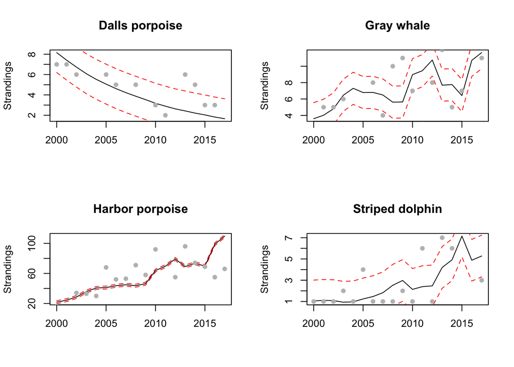

[figure not shown]

```
## Warning! Reached maxit before parameters converged. Maxit was 1000.
##  neither abstol nor log-log convergence tests were passed.
##
## MARSS fit is
## Estimation method: kem
## Convergence test: conv.test.slope.tol = 0.5, abstol = 0.001
## WARNING: maxit reached at  1000  iter before convergence.
##  Neither abstol nor log-log convergence test were passed.
##  The likelihood and params are not at the ML values.
##  Try setting control$maxit higher.
## Log-likelihood: -1906.133
## AIC: 3854.267   AICc: 3855.305
##
##                                          Estimate
## R.diag                                   3.699035
## B.(X.Dalls porpoise,X.Dalls porpoise)    1.001940
## B.(X.Gray whale,X.Gray whale)            0.998617
## B.(X.Harbor porpoise,X.Harbor porpoise)  0.988082
## B.(X.Striped dolphin,X.Striped dolphin)  0.998107
## Q.(X.Dalls porpoise,X.Dalls porpoise)    0.018197
## Q.(X.Gray whale,X.Gray whale)            0.000577
## Q.(X.Harbor porpoise,X.Harbor porpoise)  0.019327
## Q.(X.Striped dolphin,X.Striped dolphin)  0.000307
## x0.X.Dalls porpoise                     -2.711669
## x0.X.Gray whale                         -4.377972
## x0.X.Harbor porpoise                    -3.752100
## x0.X.Striped dolphin                    -4.367967
## C.(X.Dalls porpoise,cos.t)              -0.176315
## C.(X.Gray whale,cos.t)                   0.368605
## C.(X.Harbor porpoise,cos.t)             -0.203153
## C.(X.Striped dolphin,cos.t)              0.155509
## C.(X.Dalls porpoise,sin.t)               0.266588
## C.(X.Gray whale,sin.t)                   0.789547
## C.(X.Harbor porpoise,sin.t)              0.759425
## C.(X.Striped dolphin,sin.t)             -0.195582
## Initial states (x0) defined at t=0
##
## Standard errors have not been calculated.
## Use MARSSparamCIs to compute CIs and bias estimates.
##
## Convergence warnings
##  Warning: the  Q.(X.Gray whale,X.Gray whale)  parameter value has not converged.
##  Warning: the  Q.(X.Striped dolphin,X.Striped dolphin)  parameter value has not converged.
##  Warning: the  logLik  parameter value has not converged.
##  Type MARSSinfo("convergence") for more info on this warning.
```

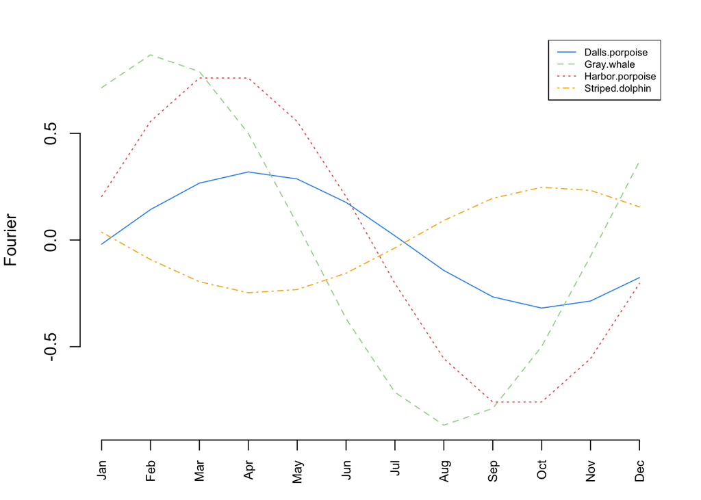

### Introduction

Over the past several decades, stranding records have been used as an indicator of ocean and marine mammal health (Bogomolni et al., 2010; Bossart, 2011; Gulland & Hall, 2007). Examining where, when, and how often marine mammals strand can provide insight into ecological behaviors, reproductive success, (Norman et al., 2004; Pikesley et al., 2011), the impacts of human activities (Warlick et al., 2018), and species distributions (Evans et al., 2005; MacLeod et al., 2005). Pinnipeds and cetaceans are strongly influenced by changes in the marine environment via diverse and dynamic mechanisms, including changes in sea surface temperature, winds, or large-scale oceanographic oscillations that can shift the balance of nutrients and prey species abundance and distribution. These small changes are often amplified up through the food web or exacerbated by increased pollutants or algal blooms, ultimately having noticeable effects on top predators. Analyzing changes in strandings over time provides important information for monitoring abundance trends and examining emerging diseases, particularly in light of recent documented changes in oceanographic conditions on both local and regional scales (Pierce, Santos, Smeenk, Saveliev, & Zuur, 2007; Sprogis, Christiansen, Wandres, & Bejder, 2017; Truchon et al. 2013). In this study, I examined temporal trends in stranding records for cetaceans and pinnipeds in the Pacific Northwest to investigate whether strandings have changed over time, exhibit a seasonal pattern, or correlate to prevailing oceanographic conditions.

As top predators of their respective food webs, marine mammals may be especially sensitive to oceanographic changes (Evans, Pierce, & Panigada, 2010; Moore 2008). Recent studies have found correlations between long-term stranding trends and several indices of climatic variability, demonstrating how strandings may be used as bio-indicators of prevailing environmental conditions. Evans et al. (2005) found that cetacean strandings in southeast Australia exhibited a periodicity coincident with regional wind patterns. Factors such as sea ice and the North Atlantic Oscillation have been found to correlate with strandings and mortality of certain pinniped and cetacean species in the Gulf of St. Lawrence, Canada (Johnston, Bowers, Friedlaender, & Lavigne, 2012; Soulen, Cammen, Schultz, & Johnston, 2013; Truchon et al. 2013). Keledjian and Mesnick (2013) found that El Niño conditions corresponded with increased California sea lion (*Zalophus californianus*) strandings and fisheries interactions along the California coast. Berini, Kracker, & McFee (2015) found that pygmy whale strandings in the southeast U.S. were correlated with sea surface temperatures, wind, and other oceanographic indicators. Gray whale (*Eschrichtius robustus*) mother-calf pair counts in their summer feeding grounds have been linked to sea ice conditions during the previous feeding season, while distribution of mother-calf pairs in some calving areas in Mexico are influenced by ENSO-related variability (Salvadeo, Nájera-Caballero, Urbán-Ramirez, & Lluch-Belda, 2015). Because responses to environmental change are complex, variable, species-dependent, and often poorly understood, oceanographic features should be studied over varying scales (local and continental), ecotypes, and species (Evans & Bjørge, 2013; Laidre, Stirling, Lowry, Wiig, Heide-Jørgensen, & Ferguson, 2008; Truchon et al. 2013).

Environmental changes are acknowledged to be occurring on a global scale (IPCC, 2014), though the local realization of these changes is patchy and difficult to predict due to varying degrees of ecosystem complexity and spatial heterogeneity (Evans and Bjørge, 2013; Jacox et al., 2016; Moore, 2008). In recent years, the California Current ecosystem experienced an “extreme marine heat wave” that became known as The Blob, where above average water temperatures persisted from 2014-2016, causing a wide range of changes, including shifts in primary production, fish spawning, larval abundance, and marine wildlife health (Auth, Daly, Brodeur, & Fisher, 2017; Bond, Cronin, Freeland, & Mantua, 2015; DiLorenzo & Mantua, 2016). These conditions along the U.S. West Coast in addition to increasing ocean acidification and harmful algal blooms in the Pacific Northwest (Mauger et al., 2015; Mote & Salathé, 2010) can negatively impact marine mammal population dynamics through changes in the abundance and distribution of their prey, among other effects. Increases in harbor porpoise (*Phocoena phocoena*) strandings over the last 12 years in the Pacific Northwest have been posited to be partially due to changes in their prey’s abundance and distribution (Greene, Kuehne, Rise, Fresh, & Penttila, 2015; Jefferson, Smultea, Courbis, & Campbell, 2016). The Pacific Northwest encompasses coastal, inland, and estuarine waters extending from northern California through British Columbia, including the Salish Sea and the mouth of the Columbia River. It is an ecosystem that contains important feeding and breeding habitat for numerous marine mammal species in the eastern north Pacific and beyond, including gray (*Eschrichtius robustus*) and humpback (*Megaptera novaeangliae*) whales, endangered southern resident killer whales (*Orcinus orca*), and numerous smaller delphinid and phocoenid species.

### Methods

#### Environmental data

##### Local oceanographic conditions and prey densities

Sea surface temperature (SST) values were obtained from northern California (buoy 46014, 39N/124W) and central Oregon (buoy 46050, 45N/125W) from the California Current Integrated Ecosystem Assessment project data portal. Data for SST was z-score stanrdardized by subtracting a given month SST value from a long-term (since 1981) mean SST in that month (e.g., mean of all Januaries 1981-2017 minus January 2005). Monthly upwelling values (from 39ºN/125ºW and 45ºN/125ºW) were included because seasonal upwelling in the California Current greatly drives primary production and fish prey density along the West Coast. Meridional winds at 39ºN and 45ºN were initially investigated but ultimately omitted due to strong correlation with upwelling values.

##### Large-scale oceanographic oscillations

Variables used to assess the effect of large-scale, climatic factors on strandings included: (1) the Multivariate ENSO index (MEI) index, (2) the Pacific Decadal Oscillation (PDO) index, and (3) the North Pacific Gyre Oscillation (NPGO) index, all of which were obtained from the California Current IEA at the monthly level. The MEI describes ENSO conditions since it combines six meteorological measures over portions of the Pacific Ocean (Wolter & Timlin, 1993). Large positive MEI values indicate the occurrence of El Niño conditions, while large negative MEI values indicate La Niña conditions. The presence of El Niño conditions was also included as a categorical variable. The PDO represents a recurring pattern of climate variability (Mantua & Hare, 2002) with historical records strongly suggesting an association with salmon production (Beamish et al., 1999; Hare, Mantua, & Francis, 1999) and zooplankton production in the eastern North Pacific (Francis, Hare, Hollowed, & Wooster, 2003). The NPGO is largely driven by sea surface height variability and is thought to influence salinity and nutrient concentrations (DiLorenzo et al. 2008). Oceanographic indices were examined in real-time and with 1-5 month lags while prey density variables were only considered in real-time. Because many of the oceanographic variables are inter-related, I tested for collinearity between variables. The larger number of potential covariates were considered due to the wide range of cetacean and pinniped species with different life histories and behaviors that could be influenced by environmental conditions at varying spatial and temporal scales.

##### Statistical analysis

$$\begin{equation}
\begin{gathered}
\mathbf{x}_t = \mathbf{B} \mathbf{x}_{t-1}+\mathbf{u}+\mathbf{C_t}\mathbf{c_t} +\mathbf{w}_t \text{ where } \mathbf{w}_t \sim \,\text{MVN}(0,\mathbf{Q}) \\
\mathbf{y}_t = \mathbf{Z}\mathbf{x}_t+\mathbf{a}+\mathbf{v}_t \text{ where } \mathbf{v}_t \sim \,\text{MVN}(0,\mathbf{R}) \\
\mathbf{x}_0 = \boldsymbol{\mu}
\end{gathered}
\end{equation}$$

To examine seasonal effects, I included a discrete Fourier series as a covariate in the marss() model specification. The Fourier series is a combination of sine and cosine waves that results in a smoothed estimated effect with far fewer parameters being estimated compared to a fixed seasonal effect. In order to ascertain what lag times should be considered for oceanographic indices, I examined the correlation between the state residuals for the seasonal effects model and PDO, MEI, SST, and upwelling data with 0-5 month lag times. Lagged covariates with the highest correlation were tested and compared.

Once the best model was identified using AICc values, other variance structures for the state process error were explored. Process errors in the Q matrix could either be (a) independent with equal variances across species, (b) independent with unique variance for each species, or (c) correlated with equal variance. Models were fit using `marss()` in the MARSS R package (Holmes et al. ), which maximizes likelihoods based on an expectation-maximization algorithm and Kalman filter. Models were compared using Akaike’s Information Criterion-based model selection to assess and quantify support for various models of the underlying stranding process across marine mammal species.

Though using a MARSS model approach to examine whether stranding patterns exhibit spatial patterns is currently outside the scope of this study, hotspot maps were generated (`geom_density2d` function in the ggplot2 R package) using kernel density estimation (Gatrell, Bailey, Diggle, & Rowlingson, 1996).

### Discussion

Temporal trends: - Do seasonal stranding patterns reflect what we understand about seasonal presence/absence of species in the area? Why or why not?

Geographic trends: - Could combine and answer this in one category of spatio-temporal trends, since they are so closely related, but same question as above, do geographic trends reflect what we generally think we know about the spatial extent of these species? Why or why not? Range expansions or other HI-related issues?

Ocean: - Without fixating on the models too much (I personally am still on the fence about model selection, AIC, my own skills, etc., so I’m not sure how much to say here, but at least: o Species are all different and would theoretically respond to different environmental conditions at different spatial and temporal scales. o Find something to say about the models for each species, and particularly interesting that most of the covariates don’t seem to have a very large effect size, though most are negative? - Could spend at least a paragraph or two outlining future steps/possibilities o Better prey availability metrics o Longer timeseries consideration would be better for oceanographic indices o Stronger methodological pairing between where/when conditions are experienced compared with where/when strandings are reported (drift, lag, etc.) o Better description of why we think this matters for a few of the species – why would california current prey density matter, etc? o How might be comment on or tie back to future climate variability/change?

[figure not shown]

#### Acknowledgements

This research was made possible through the hard work and dedication of all stranding response network work members in the Pacific Northwest, including Cascadia Research Collective, Central Puget Sound Marine Mammal Stranding Network, Dungeness National Wildlife Refuge & Protection Island, Feiro Marine Life Center, Makah Tribe, Marine Animal Rescue Center, MaST Center Stranding Team, Olympic Coast National Marine Sanctuary, Oregon State University Marine Mammal Institute, Port Townsend Marine Science Center, Portland State University, San Juan County Marine Mammal Stranding Network, Seal Sitters, Seaside Aquarium, Sno-King Marine Mammal Response, The Whale Museum, Vashon Hydrophone Project, Washington Dept of Fish and Wildlife Marine Mammal Investigations, and Whatcom Marine Mammal Stranding Network. In addition to the numerous volunteer hours invested in collecting the data presented, many stranding networks were the recipients of numerous U.S. Federal grants through the John H. Prescott Marine Mammal Rescue Assistance Grant Program, which supplied essential funding for this work.

#### References

Akaike, H. (1973). Information theory and an extension of maximum likelihood principle. In B. N. Petrov & F. Csaki (Eds.), Second International Symposium on Information Theory (pp. 267-281). Budapest, Hungary: Akademiai Kiado.

Auth, T. D., Daly, E. A., Brodeur, R. D., & Fisher, J. L. (2017). Phenological and distributional shifts in ichthyoplankton associated with recent warming in the northeast Pacific Ocean. Global Change Biology, 24, 259-272. https://doi.org/10.1111/gcb.13872

Bakun, A. (1973). Coastal upwelling indices, west coast of North America, 1946–71. U.S. Department of Commerce, NOAA Technical Report NMFS–SSRF–671.

Beamish, R. J., Noakes, D. J., McFarlane, G. A., Klyashtorin, L., Ivanov, V. V., & Kurashov, V. (1999). The regime concept and natural trends in the production of Pacific salmon. Canadian Journal of Fisheries and Aquatic Sciences, 56, 516-526. http://www.nrcresearchpress.com/doi/10.1139/f98-200#.W3353-hKjD4

Berini, C. R., Kracker, L. M., & McFee, W. E. (2015). Modeling pygmy sperm whale (Kogia breviceps, De Blainville 1838) strandings along the southeast coast of the United States from 1992 to 2006 in relation to environmental factors. NOAA Technical Memorandum NOS NCCOS 203 (pp. 44). Charleston, SC: NOAA Technical Memorandum. Retrieved from https://doi.org/10.7289/V5/TM-NOS-NCCOS-203 (accessed 13 August 2018).

Bogomolni, A. L., Pugliares, K. R., Sharp, S. M., Patchett, K., Harry, C.T., LaRocque, J. M., Touhey, K. M., & Moore, M. (2010). Mortality trends of stranded marine mammals on Cape Cod and southeastern Massachusetts, USA, 2000 to 2006. Diseases of Aquatic Organisms, 88, 143-155. https://doi.org/10.3354/dao02146

Bond, N. A., Cronin, M. F., Freeland, H., & Mantua, N. J. (2015). Causes and impacts of the 2014 warm anomaly in the NE Paciﬁc. Geophysical Research Letters, 42, 3414-3420. doi:10.1002/2015GL063306. https://doi.org/10.1002/2015GL063306

Bond, N. A., M. F. Cronin, H. Freeland, and N. J. Mantua (2015), Causes and impacts of the 2014 warm anomaly in the NE Paciﬁc, Geophys. Res. Lett., 42, 3414–3420, doi:10.1002/2015GL063306.

Bossart, G. D. (2011). Marine mammals as sentinel species for oceans and human health. Veterinary Pathology, 48, 676-690. https://doi.org/10.1177%2F0300985810388525

Coates, K. S. (2002). 1. Border Crossings. In J. M. Findlay, & K. S. Coates (Eds.), Parallel destinies: Canadian-American relations west of the Rockies (pp. 3-30). Seattle and London: University of Washington Press.

Cotté, C., & Simard, Y. (2005). Formation of dense krill patches under tidal forcing at whale feeding hot spots in the St. Lawrence Estuary. Marine Ecology Progress Series, 288, 199-210. https://doi:10.3354/meps288199

Di Lorenzo E., Schneider N., Cobb K. M., Chhak, K, Franks P. J. S., Miller A. J., McWilliams J. C., Bograd S. J., Arango H., Curchister E., Powell T. M. and P. Rivere, 2008: North Pacific Gyre Oscillation links ocean climate and ecosystem change. Geophys. Res. Letters, 35, L08607, doi:10.1029/2007GL032838.

DiLorenzo, E., & Mantua, N. (2016). Multi-year persistence of the 2014/15 North Paciﬁc marine heatwave. Nature Climate Change, 6, 1042-1047, doi:10.1038/NCLIMATE3082.

Evans, K., Thresher, R., Warneke, R. M., Bradshaw, C. J. A., Pook, M., Thiele, D., & Hindell, M. A. (2005). Periodic variability in cetacean strandings: links to large-scale climate events. Biology Letters, 1, 147-150. https://dx.doi.org/10.1098%2Frsbl.2005.0313

Evans, P. G. H., Pierce, G. J., & Panigada, S. (2010). Climate change and marine mammals. Journal of the Marine Biological Association of the United Kingdom, 90, 1483-1487. https://doi.org/10.1017/S0025315410001815

Evans, P. G. H., & Bjørge, A. (2013). Impacts of climate change on marine mammals. Marine Climate Change Impacts Partnership: Science Review 2013, 134-148. https://doi:10.14465/2013.arc15.134-148

Fire, S. E., Wang, Z., Berman, M., Langlois, G. W., Morton, S. L., Sekula-Wood, E., & Benitez-Nelson, C. R. (2010). Trophic transfer of the harmful algal toxin domoic acid as a cause of death in a minke whale (Balaenoptera acutorostrata) stranding in southern California. Aquatic Mammals, 36, 342-350. https://doi:10.1578/AM.36.4.2010.342

Flewelling, L. J., Naar, J. P., Abbott, J. P., Baden, D. G., Barros, N. B., Bossart, G. D.,… Landsberg, J. H. (2005). Red tides and marine mammal mortalities. Nature, 435, 755-756. https://www.nature.com/articles/nature435755a

Francis, R. C., Hare, S. R., Hollowed, A. B., & Wooster, W. S. (2003). Effects of interdecadal climate variability on the oceanic ecosystems of the NE Pacific. Fisheries Oceanography, 7, 1-21. https://doi.org/10.1046/j.1365-2419.1998.00052.x

Gatrell, A. C., Bailey, T. C., Diggle, P. J., & Rowlingson, B. S. (1996). Spatial point pattern analysis and its application in geographical epidemiology. Transactions of the Institute of British Geographers, 21, 256-274. https://www.jstor.org/stable/622936

Greene, C., Kuehne, L., Rise, C., Fresh, K., & Penttila, D. (2015). Forty years of change in forage fish and jellyfish abundance across greater Puget Sound, Washington (USA): anthropogenic and climate associations. Marine Ecology Progress Series, 525, 153-170. https://doi.org/10.3354/meps11251

Gulland, F. M. D., & Hall, A. J. (2007). Is marine mammal health deteriorating? Trends in the global reporting of marine mammal disease. EcoHealth, 4, 135-150. https://doi.org/10.1007/s10393-007-0097-1

Hare, S. R., Mantua, N. J., & Francis, R. C. (1999). Inverse production regimes: Alaskan and West Coast Salmon. Fisheries, 24, 6-14. https://doi.org/10.1577/1548-8446(1999)024%3C0006:IPR%3E2.0.CO;2

Hemery, G., D’Amico, F., Castege, I., Dupont, B., D’Elbee, J., LaLanne, Y., & Mouches, C. (2008). Detecting the impact of oceano-climatic changes on marine ecosystems using a multivariate index: The case of the Bay of Biscay (North Atlantic-European Ocean). Global Change Biology, 14, 27-38. https://doi.org/10.1111/j.1365-2486.2007.01471.x

Hinrichsen, R.A. (2009) Population viability analysis for several populationsusing multivariate state-space models.Ecological Modelling,220, 1197–1202.

Hinrichsen, R.A. & Holmes, E.E. (2009) Using multivariate state-space modelsto study spatial structure and dynamics.Spatial Ecology(eds R. StephenCantrell, C. Cosner & S. Ruan), pp. 145–166. CRC⁄Chapman Hall, BocaRaton, FL.

IPCC (2014). Climate change 2014: Synthesis report. Contribution of working groups I, II and III to the fifth assessment report of the Intergovernmental Panel on Climate Change. In Core Writing Team, RKPaLaME (Ed.), Report of the Intergovernmental Panel on Climate Change. Geneva: IPCC.

Jacox, M. G., Hazen, E. L., Zaba, K. D., Rudnick, D. L., Edwards, C. A., Moore, A. M., & Bograd, S. J. (2016). Impacts of the 2015–2016 El Niño on the California Current System: early assessment and comparison to past events. Geophysical Research Letters, 43, 7072-7080. https://doi.org/10.1002/2016GL069716

Jefferson, T. A., Smultea, M. A., Courbis, S. S., & Campbell, G. S. (2016). Harbor porpoise (Phocoena phocoena) recovery in the inland waters of Washington: estimates of density and abundance from aerial surveys, 2013–2015. Canadian Journal of Zoology, 94, 505-515. https://doi.org/10.1139/cjz-2015-0236

Johnston, D. W., Bowers, M. T., Friedlaender, A. S., & Lavigne, D. M. (2012). The effects of climate change on harp seals (Pagophilus groenlandicus). PLoS One, 7, e29158. https://doi.org/10.1371/journal.pone.0029158

Keledjian, A., & Mesnick, S. L. (2013). The impacts of El Niño conditions on California sea lion (Zalophus californianus) fisheries interactions: predicting spatial and temporal hotspots along the California coast. Aquatic Mammals, 39, 221-232. https://doi:10.1578/AM.39.3.2013.221

Laidre, K. L., Stirling, I., Lowry, L., Wiig, Ø., Heide-Jørgensen, M. P., & Ferguson, S. H. (2008). Quantifying the sensitivity of arctic marine mammals to climate-induced habitat change. In H. P. Huntington & S. E. Moore (Eds.), Arctic marine mammals and climate change. Ecological Applications, 18 (Supplement), S97-S125. https://doi.org/10.1890/06-0546.1

MacLeod, C. D., Bannon, S. M., Pierce, G. J., Schweder, C., Learmonth, J. A., Herman, J. S., & Reid, R. J. (2005). Climate change and the cetacean community of north-west Scotland. Biological Conservation, 124, 477-483. https://doi.org/10.1016/j.biocon.2005.02.004

Mantua, N. J., & Hare, S. R. (2002). The Pacific Decadal Oscillation. Journal of Oceanography, 58, 35-44. https://doi.org/10.1023/A:1015820616384

Mauger, G. S., Casola, J. H., Morgan, H. A., Strauch, R. L., Jones, B., Curry, B., . . . Snover, A.K. (2015). State of Knowledge: Climate Change in Puget Sound. Report prepared for the Puget Sound Partnership and the National Oceanic and Atmospheric Administration. Climate Impacts Group, University of Washington, Seattle. doi:10.7915/CIG93777D. Retrieved from https://cig.uw.edu/resources/special-reports/ps-sok/ (accessed 2 August 2018).

Moore, S. E. (2008). Marine mammals as ecosystem sentinels. Journal of Mammalogy, 89, 534–540. https://doi.org/10.1644/07-MAMM-S-312R1.1

Mote, P. W., & Salathé Jr., E. P. (2010). Future climate in the Pacific Northwest. Climate Change, 102, 29-50. https://doi.org/10.1007/s10584-010-9848-z

Murase, H., Matsuoka, K., Ichii, T., & Nishiwaki, S. (2002). Relationship between the distribution of euphausiids and baleen whales in the Antarctic (35 degrees E-145 degrees W). Polar Biology, 25, 135-145. https://doi.org/10.1007/s003000100321

Norman, S. A., Bowlby, C. E., Brancato, M. S., Calambokidis, J., Duffield, D., Gearin, P. J., . . . Scordino, J. (2004). Cetacean strandings in Oregon and Washington between 1930 and 2002. Journal of Cetacean Research and Management, 6, 87-100.

Peterson, W. T., and J. E. Keister. (2003). Interannual variability in copepod community composition at a coastal station in the northern California Current: a multivariate approach. Deep Sea Research Part II: Topical Studies in Oceanography 50(14–16): 2499–2517.

Pierce, G. J., Santos, M. B., Smeenk, C., Saveliev, A., & Zuur, A. F. (2007). Historical trends in the incidence of strandings of sperm whales (Physeter macrocephalus) on North Sea coasts: An association with positive temperature anomalies. Fisheries Research, 87, 219-228. https://doi.org/10.1016/j.fishres.2007.06.001

Pikesley, S. K., Witt, M. J., Hardy, T., Loveridge, J., Loveridge, J., Williams, R., & Godley, B. J. (2012). Cetacean sightings and strandings: evidence for spatial and temporal trends? Journal of the Marine Biological Association of the United Kingdom, 92, 1809-1820. https://doi.org/10.1017/S0025315411000464

R Development Core Team. 2009. R: A language and environment for statistical computing. Vienna, Austria: R Foundation for Statistical Computing.

Salvadeo, C. J., Gómez-Gallardo, U. A., Nájera-Caballero, M., Urbán-Ramirez, J., & Lluch-Belda D. (2015). The effect of climate variability on gray whales (Eschrichtius robustus) within their wintering areas. PLoS One, 10, e0134655. doi:10.1371/journal.pone.0134655.

Soulen, B. K., Cammen, K., Schultz, T. F., & Johnston, D. W. (2013). Factors affecting harp seal (Pagophilus groenlandicus) strandings in the northwest Atlantic. PLoS One, 8, e68779. https://doi.org/10.1371/journal.pone.0068779.

Sprogis, K. R., Christiansen, F., Wandres, M., & Bejder, L. (2017). El Niño Southern Oscillation influences the abundance and movements of a marine top predator in coastal waters. Global Change Biology, 24, 1085-1096. https://doi.org/10.1111/gcb.13892

Truchon, M.-H., Measures, L., L’Hérault, V., Brêthes, J.-C., Galbraith, P. S., Harvey, M., . . . Lecomte, M. (2013). Marine mammal strandings and environmental changes: a 15-year study in the St. Lawrence ecosystem. PLoS One, 8, e59311. https://doi.org/10.1371/journal.pone.0059311

Warlick, A. J., Duffield, D. A., Lambourn, D. M., Jeffries, S. J., Rice, J. M., Gaydos, J. K., … Norman, S. A. (2018). Spatio-temporal characterization of pinniped strandings and human interaction cases in the Pacific Northwest, 1991-2016. Aquatic Mammals, 44, 299-318. https://doi.org/10.1578/AM.44.3.2018.299

Wolter, K., & Timlin, M. S. (1993). Monitoring ENSO in COADS with a seasonally adjusted principal component index. In Proceedings of the 17th Climate Diagnostics Workshop, NOAA/N MC/CAC, NSSL, Oklahoma Climate Survey, CIMMS and the School of Meteorology, University of Oklahoma, Norman, OK. Retrieved from https://www.esrl.noaa.gov/psd/enso/mei/WT1.pdf (accessed 18 August 2018).

Wolter, K., & Timlin, M. S. (1998). Measuring the strength of ENSO events—how does 1997/98 rank? Weather, 53, 315-324. https://doi.org/10.1002/j.1477-8696.1998.tb06408.x